# Advanced Bioinformatics 2026 assessment

K25163716

2026-04-01

## Task 3.1

The `:` operator is used to generate a sequence of all integers from 5 to 55, then pass it to the `sum()` function to calculate their total.

```r
sum(5:55)
```

```
## [1] 1530
```

## Task 3.2

The function called `sumfun` takes one input `n` and calculates the sum of all integers between 5 and `n` using the `:` operator and `sum()` function.

```r
sumfun <- function(n) {
  sum(5:n)
}
```

The function is then repeated for n = 10, n = 20 and n = 100:

```r
sumfun(10)
```

```
## [1] 45
```

```r
sumfun(20)
```

```
## [1] 200
```

```r
sumfun(100)
```

```
## [1] 5040
```

## Task 3.3

The Fibonacci sequence starts with 1,1 each subsequent number is the sum of the two preceding numbers (1,1,2,3,5…). The `for` loop is used to calculate and print the first 12 entries.

```r
fib <- c(1, 1)
for (i in 3:12) {
  fib[i] <- fib[i-1] + fib[i-2]
}
print(fib)
```

```
##  [1]   1   1   2   3   5   8  13  21  34  55  89 144
```

## Task 3.4

Using the `mtcars` dataset a boxplot of miles per gallon (`mgp`) is generated as a function of number of gears (`gear`).To make it readable and colourful `fill` will colour each box by the number of gears. The `factor()` function is used to tell R to treat `gear` as a category rather than a number.

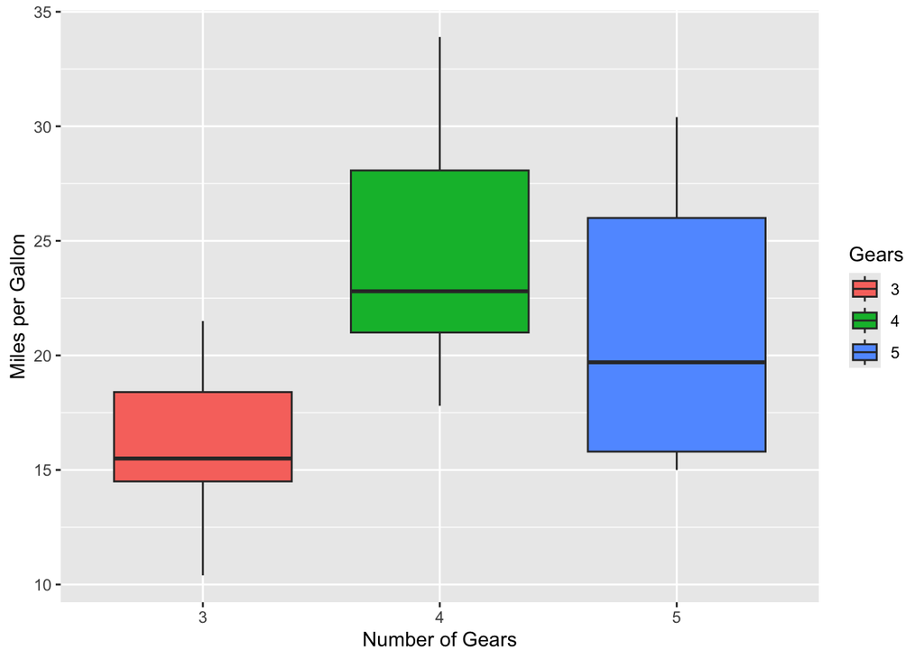

```r
library(ggplot2)

ggplot(mtcars, aes(x = factor(gear), y = mpg, fill = factor(gear))) +
  geom_boxplot() +
  labs(x = "Number of Gears", y = "Miles per Gallon", fill = "Gears")
```

## Task 3.5

The `lm()` function is used to fit a linear relationship between speed and braking distance in the `cars` dataset. Speed is measured in **mph** and distance in **feet**.

```r
model <- lm(dist ~ speed, data = cars)
summary(model)
```

```
##
## Call:
## lm(formula = dist ~ speed, data = cars)
##
## Residuals:
##     Min      1Q  Median      3Q     Max
## -29.069  -9.525  -2.272   9.215  43.201
##
## Coefficients:
##             Estimate Std. Error t value Pr(>|t|)
## (Intercept) -17.5791     6.7584  -2.601   0.0123 *
## speed         3.9324     0.4155   9.464 1.49e-12 ***
## ---
## Signif. codes:  0 '***' 0.001 '**' 0.01 '*' 0.05 '.' 0.1 ' ' 1
##
## Residual standard error: 15.38 on 48 degrees of freedom
## Multiple R-squared:  0.6511, Adjusted R-squared:  0.6438
## F-statistic: 89.57 on 1 and 48 DF,  p-value: 1.49e-12
```

The fitted intercept is -17.5791 (standard error: 6.7584) and the slope is 3.9324 (standard error: 0.4155). This means for every 1 mph increase in speed, braking distance increases by approximately 3.93 feet.

## Task 3.6

The installed `ggplot2` package is used to plot the data points from the `cars` dataset and overlay the linear fit from **Task 3.5** using `geom_smooth()`.

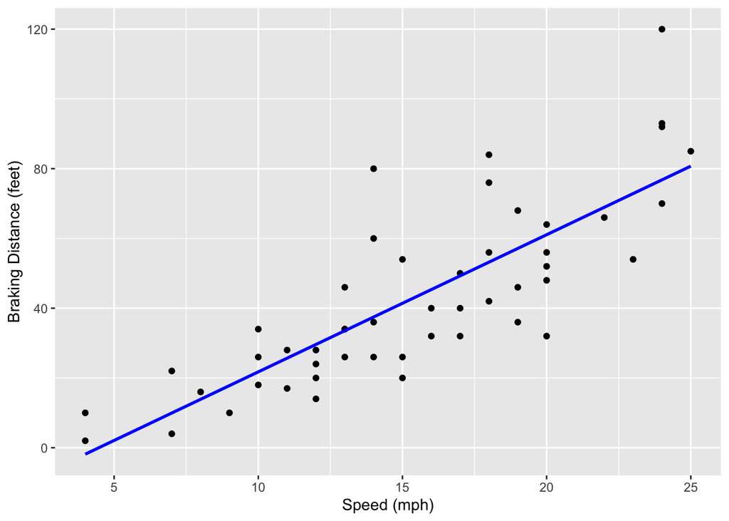

```r
ggplot(cars, aes(x = speed, y = dist)) +
  geom_point() +
  geom_smooth(method = "lm", se = FALSE, colour = "blue") +
  labs(x = "Speed (mph)", y = "Braking Distance (feet)")
```

## Task 3.7

To estimate the reaction time, braking distance is assumed as proportional to speed squared. The total stopping distance is modelled as: distance = reaction_time × speed + k × speed². This is fitted using `lm()` with no intercept (`~ 0`) because the model assumes that at zero speed, stopping distance is zero which meaning no intercept is physically meaningful here.

```r
model2 <- lm(dist ~ 0 + speed + I(speed^2), data = cars)
summary(model2)
```

```
##
## Call:
## lm(formula = dist ~ 0 + speed + I(speed^2), data = cars)
##
## Residuals:
##     Min      1Q  Median      3Q     Max
## -28.836  -9.071  -3.152   4.570  44.986
##
## Coefficients:
##            Estimate Std. Error t value Pr(>|t|)
## speed       1.23903    0.55997   2.213  0.03171 *
## I(speed^2)  0.09014    0.02939   3.067  0.00355 **
## ---
## Signif. codes:  0 '***' 0.001 '**' 0.01 '*' 0.05 '.' 0.1 ' ' 1
##
## Residual standard error: 15.02 on 48 degrees of freedom
## Multiple R-squared:  0.9133, Adjusted R-squared:  0.9097
## F-statistic: 252.8 on 2 and 48 DF,  p-value: < 2.2e-16
```

The coefficient for `speed` is 1.23903, which represents reaction distance per mph. Converting to seconds (dividing by 1.467, since 1 mph = 1.467 ft/s) gives an estimated reaction time of approximately 0.845 seconds. This is a reasonable result as typical human reaction time is between 0.7 and 1.5 seconds. The coefficient for `speed^2` is 0.09014, representing the braking component of stopping distance.

The next step involved ploting the data points and the fitted relationship:

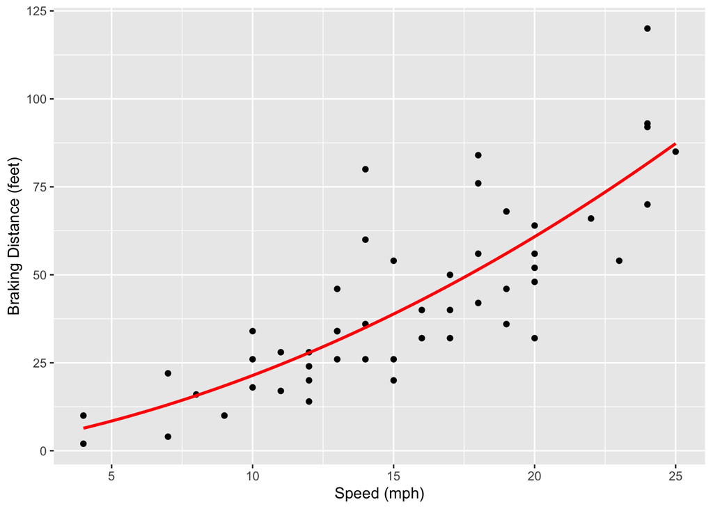

```r
ggplot(cars, aes(x = speed, y = dist)) +
  geom_point() +
  geom_smooth(method = "lm", formula = y ~ 0 + x + I(x^2),
              se = FALSE, colour = "red") +
  labs(x = "Speed (mph)", y = "Braking Distance (feet)")
```

## Task 3.8

The count data and sample description files using `read.csv()` and `read.table()` respectively are used.

```r
counts <- read.csv("data/exercise1_counts.csv", row.names = 1)

sample_info <- read.table("data/exercise1_sample_description.info",
                          header = TRUE, sep = "\t")
```

## Task 3.9

`col_data` is created from the sample description file, which will be used to describe the columns of the count matrix. The dimensions of both objects are then checked to make sure they match.

```r
col_data <- data.frame(sample_info)
dim(counts)
```

```
## [1] 26301     9
```

```r
dim(col_data)
```

```
## [1] 9 4
```

The counts matrix contains 26,301 genes across 9 samples. The col_data object contains 9 rows (one per sample) and 4 columns describing each sample. The number of samples match confirming the data is compatible for DESeq2 analysis.

## Task 3.10

A DESeqDataSet object is constructed using the count data and sample description. The `condition` column is used as the design variable, which tells DESeq2 which groups to compare.

```r
library(DESeq2)
dds <- DESeqDataSetFromMatrix(countData = counts,
                              colData = col_data,
                              design = ~ condition)
dds
```

```
## class: DESeqDataSet
## dim: 26301 9
## metadata(1): version
## assays(1): counts
## rownames(26301): 497097 100503874 ... 100040384 100040400
## rowData names(0):
## colnames(9): control_FFa1.bam control_FFa2.bam ... mutant_KOb2.bam
##   mutant_KOb3.bam
## colData names(4): filename sample condition batch
```

## Task 3.11

rlog (regularised log) and VST (Variance Stabilizing Transformation) transformations are performed on the DESeq2 object. Raw count data from RNA-seq experiments has a mean-variance relationship where highly expressed genes show much higher variance than lowly expressed ones. Both transformations address this by stabilising the variance across the range of mean expression values, making the data suitable for visualisation and clustering. rlog is preferred for smaller datasets (n < 30 samples) as it is more robust, while VST is faster and better suited to larger datasets. Both are applied here for comparison.

```r
rlog_data <- rlog(dds, blind = TRUE)
vst_data <- vst(dds, blind = TRUE)
```

## Task 3.12

A heatmap of the top 40 most highly expressed genes is drawn using both rlog and VST transformed data. The top 40 genes are selected using `rowMeans()` to calculate average expression per gene focusing on the most highly expressed genes allows clearer visualisation of expression patterns across samples. Hierarchical clustering is applied to both rows (genes) and columns (samples) to group genes with similar expression profiles and reveal whether samples cluster by condition. This is a useful quality control step to check that biological replicates behave consistently and that conditions are separating as expected.

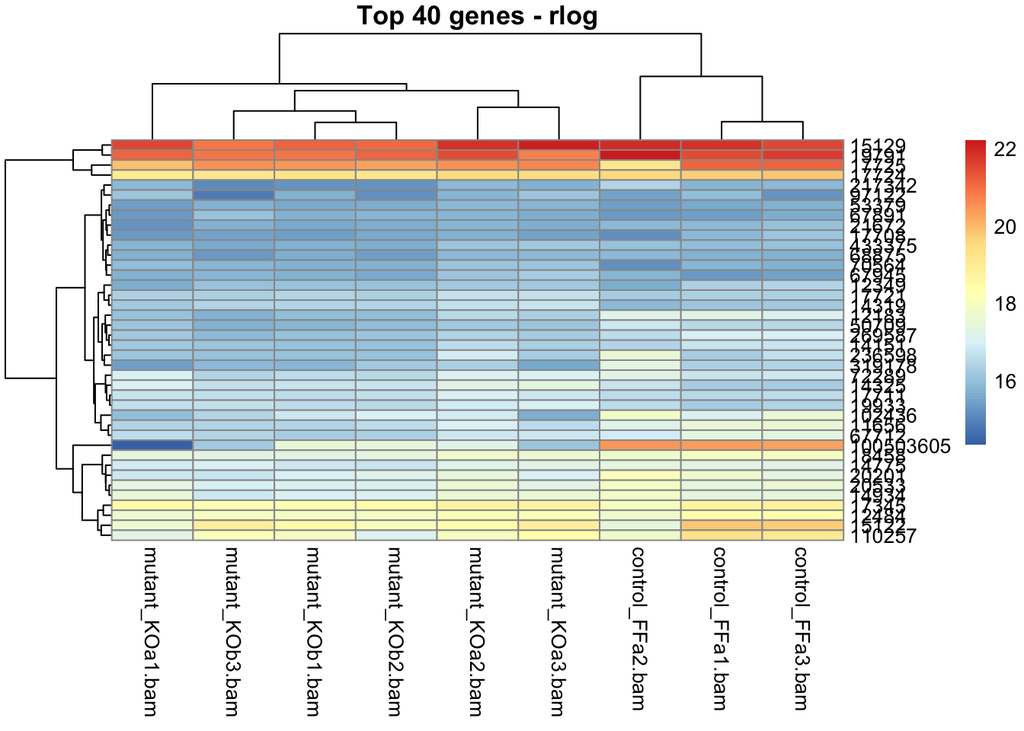

```r
library(pheatmap)

# Heatmap using rlog data
top40_rlog <- head(order(rowMeans(assay(rlog_data)), decreasing = TRUE), 40)
pheatmap(assay(rlog_data)[top40_rlog, ],
         cluster_rows = TRUE,
         cluster_cols = TRUE,
         main = "Top 40 genes - rlog")
```

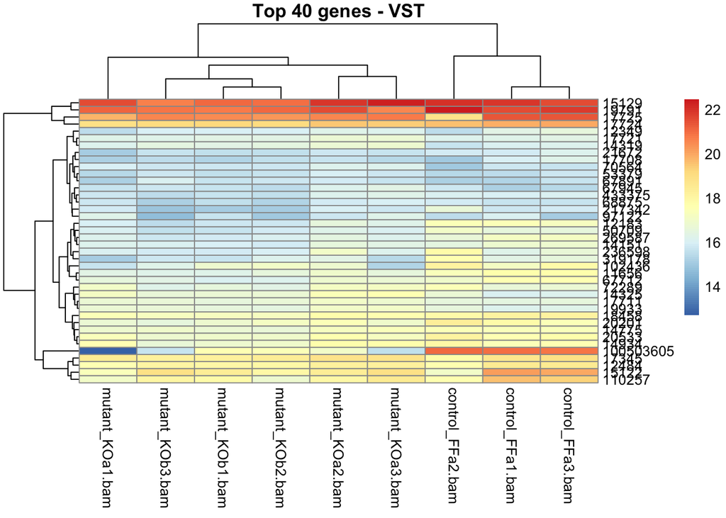

```r
# Heatmap using VST data
top40_vst <- head(order(rowMeans(assay(vst_data)), decreasing = TRUE), 40)
pheatmap(assay(vst_data)[top40_vst, ],
         cluster_rows = TRUE,
         cluster_cols = TRUE,
         main = "Top 40 genes - VST")
```

## Task 3.13

A Sample Distance Matrix (SDM) is generated to visualise the similarity and dissimilarity between all pairs of samples. The `dist()` function calculates Euclidean distances between samples using the rlog transformed data, the smaller the distance, the more similar two samples are. This is an important quality control step as it allows us to verify that biological replicates cluster together and that the two conditions (control and mutant) are clearly separated from each other. The `RColorBrewer` package is used to apply a blue colour scale where darker blue indicates greater similarity (smaller distance) and lighter blue indicates greater dissimilarity.

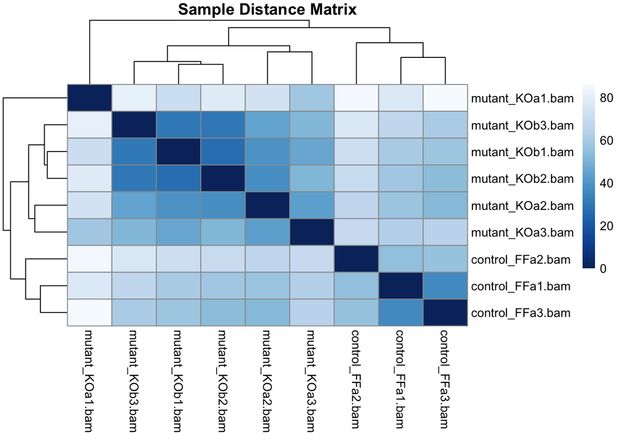

```r
library(RColorBrewer)

sampleDists <- dist(t(assay(rlog_data)))
sampleDistMatrix <- as.matrix(sampleDists)

colors <- colorRampPalette(rev(brewer.pal(9, "Blues")))(255)

pheatmap(sampleDistMatrix,
         clustering_distance_rows = sampleDists,
         clustering_distance_cols = sampleDists,
         col = colors,
         main = "Sample Distance Matrix")
```

## Task 3.14

Principal Component Analysis (PCA) is performed using the rlog transformed data. PCA is a dimensionality reduction technique that transforms the data into a set of uncorrelated variables called principal components, ordered by the amount of variance they explain. This allows visualisation of the major sources of variation between samples in a 2D plot. PC1 captures the largest source of variation in the data, and PC2 the second largest. If the experiment is well designed, samples should cluster by condition along PC1. The `plotPCA()` function from DESeq2 uses the top 500 most variable genes by default, which focuses the analysis on the most informative genes.

```
## using ntop=500 top features by variance
```

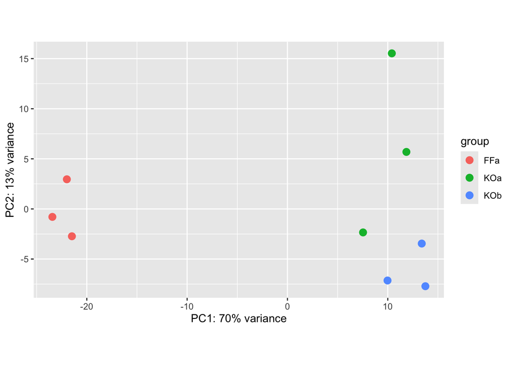

```r
plotPCA(rlog_data, intgroup = "condition")
```

```r
pca_data <- prcomp(t(assay(rlog_data)))
pca_var <- pca_data$sdev^2 / sum(pca_data$sdev^2) * 100
cat("PC1:", round(pca_var[1], 1), "%\n")
```

```
## PC1: 35 %
```

```r
cat("PC2:", round(pca_var[2], 1), "%\n")
```

```
## PC2: 31.4 %
```

## Task 3.15

The PCA is repeated using VST transformed data to allow comparison with the rlog method used in Task 3.14. While both transformations aim to stabilise variance, they use different mathematical approaches and may produce slightly different results. Comparing the two PCA plots allows assessment of whether the choice of normalisation method affects the biological conclusions drawn from the data.

```
## using ntop=500 top features by variance
```

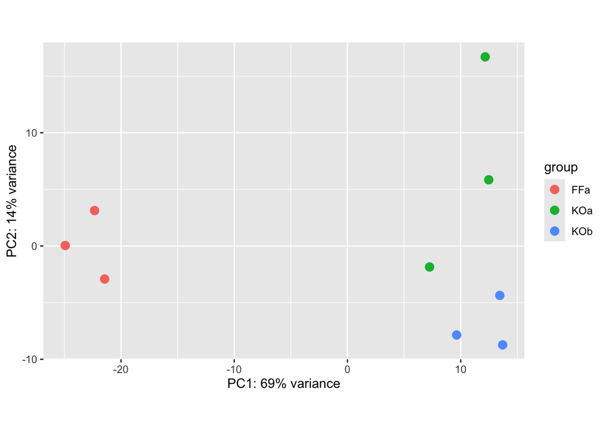

```r
plotPCA(vst_data, intgroup = "condition")
```